# Predicting Exercise Performance

- Date: February 4, 2017
- **[Code](https://github.com/danvargg/folio/tree/master/Pml)**
- Category: Machine Learning
- Technologies: R, Caret
- Algorithms: Decision Trees, Random Forests

## Introduction

Using devices such as *Jawbone Up*, *Nike FuelBand*, and *Fitbit* it is now possible to collect a large amount of data about personal activity relatively inexpensively. These type of devices are part of the quantified self movement – a group of enthusiasts who take measurements about themselves regularly to improve their health and to find patterns in their behavior. One thing that people regularly do is quantify how much of a particular activity they do, but they rarely quantify how well they do it. In this project, I will be to use data from accelerometers on the belt, forearm, arm, and dumbell of 6 participants, and predict the manner in which they did the exercise. This is the `classe` variable in the training set. They were asked to perform barbell lifts correctly and incorrectly in 5 different ways. More information is available from the website **[here](http://groupware.les.inf.puc-rio.br/har)**.

- The training data for this project are available **[here](https://d396qusza40orc.cloudfront.net/predmachlearn/pml-training.csv)**
- The test data are available **[here](https://d396qusza40orc.cloudfront.net/predmachlearn/pml-testing.csv)**
- The data for this project come from this **[source](http://groupware.les.inf.puc-rio.br/har)**

## Processing the Data

#### Loading the Data

```r
traindata <- read.csv(
        "https://d396qusza40orc.cloudfront.net/predmachlearn/pml-training.csv",
        na.strings = c("NA", "#DIV/0!", ""))
testdata <- read.csv(
        "https://d396qusza40orc.cloudfront.net/predmachlearn/pml-testing.csv",
        na.strings = c("NA", "#DIV/0!", ""))
```

#### Cleaning the Data

Removing the predictors not used as part of this analysis (1 ~ 7).

```r
traindata2 <- traindata[, -c(1:7)]
testdata2 <- testdata[, -c(1:7)]
```

Creating a data partition for cross validation.

```r
library(caret)
intrain <- createDataPartition(traindata2$classe, p = 0.7, list = FALSE)
train <- traindata2[intrain, ]
test <- traindata2[-intrain, ]
dim(train); dim(test)
```

```
## [1] 13737   153
```

```
## [1] 5885  153
```

Removing `NearZeroVariance` variables.

```r
nzv <- nearZeroVar(train, saveMetrics = TRUE)
train <- train[, nzv$nzv == FALSE]

nzv <- nearZeroVar(test, saveMetrics = TRUE)
test <- test[, nzv$nzv == FALSE]
```

Removing variables with more than 60% `NA`.

```r
train2 <- train
for(i in 1:length(train)) {
    if(sum(is.na(train[, i]))/nrow(train) >= 0.6) {
        for(j in 1:length(train2)) {
            if(length(grep(names(train[i]), names(train2)[j])) == 1) {
                train2 <- train2[ , -j]
            }
        }
    }
}
train <- train2
```

## Predicting with Decision Trees

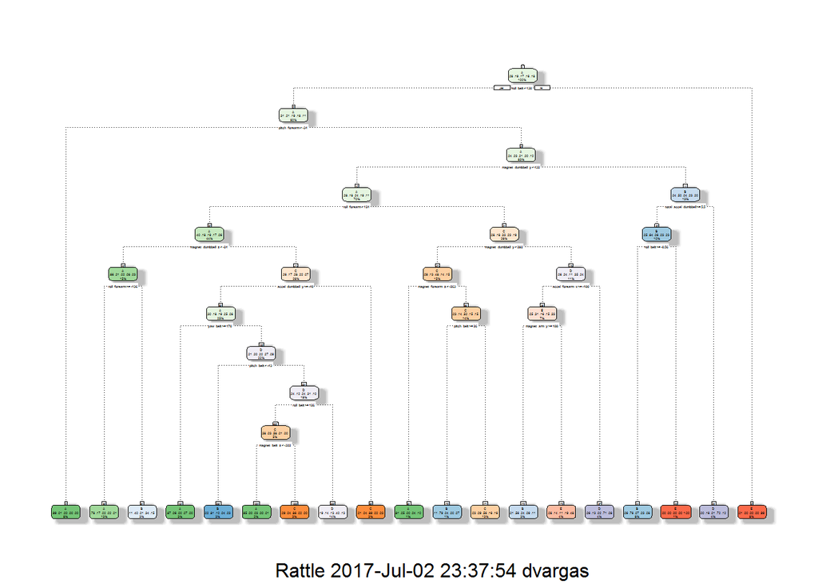

```r
set.seed(20170204)
library(rpart)
library(rpart.plot)
library(rattle)
tree <- rpart(classe ~ ., data = train, method = "class")
fancyRpartPlot(tree)
```

Decision Tree Prediction.

```r
treep <- predict(tree, test, type = "class")
confusionMatrix(treep, test$classe)
```

```
## Confusion Matrix and Statistics
##
##           Reference
## Prediction    A    B    C    D    E
##          A 1350  141   16   30    8
##          B   59  672   91   88  100
##          C   45   96  775  158  115
##          D  204  193  117  650  152
##          E   16   37   27   38  707
##
## Overall Statistics
##
##                Accuracy : 0.7059
##                  95% CI : (0.694, 0.7175)
##     No Information Rate : 0.2845
##     P-Value [Acc > NIR] : < 2.2e-16
##
##                   Kappa : 0.6298
##  Mcnemar's Test P-Value : < 2.2e-16
##
## Statistics by Class:
##
##                      Class: A Class: B Class: C Class: D Class: E
## Sensitivity            0.8065   0.5900   0.7554   0.6743   0.6534
## Specificity            0.9537   0.9288   0.9148   0.8647   0.9754
## Pos Pred Value         0.8738   0.6653   0.6518   0.4939   0.8570
## Neg Pred Value         0.9253   0.9042   0.9466   0.9313   0.9259
## Prevalence             0.2845   0.1935   0.1743   0.1638   0.1839
## Detection Rate         0.2294   0.1142   0.1317   0.1105   0.1201
## Detection Prevalence   0.2625   0.1716   0.2020   0.2236   0.1402
## Balanced Accuracy      0.8801   0.7594   0.8351   0.7695   0.8144
```

## Predicting with Random Forests

```r
library(randomForest)
forest <- randomForest(classe ~. , data = train)
```

Random Forests Prediction.

```r
forest1 <- predict(forest, test, type = "class")
confusionMatrix(forest1, test$classe)
```

```
## Confusion Matrix and Statistics
##
##           Reference
## Prediction    A    B    C    D    E
##          A 1674    4    0    0    0
##          B    0 1134    5    0    0
##          C    0    1 1017   10    1
##          D    0    0    4  953    2
##          E    0    0    0    1 1079
##
## Overall Statistics
##
##                Accuracy : 0.9952
##                  95% CI : (0.9931, 0.9968)
##     No Information Rate : 0.2845
##     P-Value [Acc > NIR] : < 2.2e-16
##
##                   Kappa : 0.994
##  Mcnemar's Test P-Value : NA
##
## Statistics by Class:
##
##                      Class: A Class: B Class: C Class: D Class: E
## Sensitivity            1.0000   0.9956   0.9912   0.9886   0.9972
## Specificity            0.9991   0.9989   0.9975   0.9988   0.9998
## Pos Pred Value         0.9976   0.9956   0.9883   0.9937   0.9991
## Neg Pred Value         1.0000   0.9989   0.9981   0.9978   0.9994
## Prevalence             0.2845   0.1935   0.1743   0.1638   0.1839
## Detection Rate         0.2845   0.1927   0.1728   0.1619   0.1833
## Detection Prevalence   0.2851   0.1935   0.1749   0.1630   0.1835
## Balanced Accuracy      0.9995   0.9973   0.9944   0.9937   0.9985
```

## Predicting on the Test Data

```r
p1 <- predict(forest, testdata, type = "class")
head(p1, 20)
```

```
##  1  2  3  4  5  6  7  8  9 10 11 12 13 14 15 16 17 18 19 20
##  B  A  B  A  A  E  D  B  A  A  B  C  B  A  E  E  A  B  B  B
## Levels: A B C D E
```